# DC_1-Notebook

# INDEX

1. **Basic mapping with ggplot2** -> 100%
2. Point and polygon data -> 75%
3. Raster data and color -> 0%
4. Data import and projections-> 30%

## 1. Basic mapping with ggplot2 and ggmap

### basic **ggmap::get_map** function -> ARGUMENTS

The most important arguments are:

- *location*, where you can provide a longitude and latitude pair of coordinates where you want the map centered. (We found these for NYC from a quick google search of “coordinates nyc”.)
- The next argument, *zoom*, takes an integer between 3 and 21 and controls how far the mapped is zoomed in.
- In this exercise, you’ll set a third argument, *scale*, equal to 1. This controls the resolution of the downloaded maps and you’ll set it lower (the default is 2) to reduce how long it takes for the downloads.
- *source*, Google Maps (“google”), OpenStreetMap (“osm”), Stamen Maps (“stamen”) etc

[figure not shown]

```r
library(ggmap)
corvallis <- c(lon = -123.2620, lat = 44.5646)
# Get map at zoom level 5: map_5
map_5 <- get_map(location = corvallis, zoom = 5, scale = 1)
# Plot map at zoom level 5
ggmap(map_5)
```

```r
print (map_5)
```

```
640x640 terrain map image from Google Maps.  see ?ggmap to plot it.
```

[figure not shown]

```r
# Get map at zoom level 13: corvallis_map
corvallis_map <- get_map(location = corvallis, zoom = 13, scale = 1)
# Plot map at zoom level 13
ggmap(corvallis_map)
```

```r
print(corvallis_map)
```

```
640x640 terrain map image from Google Maps.  see ?ggmap to plot it.
```

[figure not shown]

```r
# check possible baselayers
?get_map
# Add a maptype argument to get a satellite map
corvallis_map_sat <- get_map(corvallis, zoom = 13, maptype = "satellite")
ggmap(corvallis_map_sat)
```

```r
# Non ho il DS

# Edit to get display satellite map
ggmap(corvallis_map_sat) +
  geom_point(aes(lon, lat, color = year_built), data = sales)
```

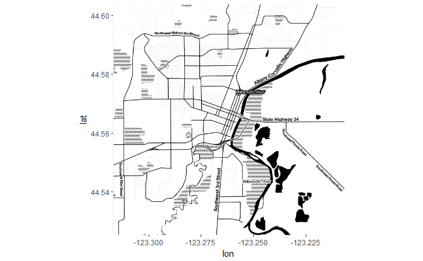

```r
# Add source and maptype to get toner map from Stamen Maps
corvallis_map_bw <- get_map(corvallis, zoom = 13,
                            source = "stamen",
                            maptype = "toner")
ggmap(corvallis_map_bw)
```

```r
# Edit to display toner map
# ggmap(corvallis_map_bw) + geom_point(aes(lon, lat, color = year_built), data = sales)
```

### Adding points to the map

Similar to ggplot(), you can add layers of data to a **ggmap()** call (e.g. + geom_point()). It’s important to note, however, that ggmap() sets the map as the default dataset and also sets the default aesthetic mappings.

*This means that if you want to add a layer from something other than the map (e.g. sales), you need to explicitly specify both the mapping and data arguments to the geom*

- method 1: ggplot(sales, aes(lon, lat)) + geom_point()
- method 2: ggplot() + geom_point(aes(lon, lat), data = sales)

The benefit of specifying the plot in the 2nd way is you can swap out ggplot() for a call to ggmap() and get a map in the background of the plot.

```r
# Look at head() of sales
head(sales)

# BEFORE using ggplot would be like this
ggplot() +
  geom_point(aes(lon, lat), data = sales)


# AFTER Swap out call to ggplot() with call to ggmap()
ggmap(corvallis_map) +
  geom_point(aes(lon, lat), data = sales)
```

#### USING COLORS AND SHAPES TO OVERLAP DATA elements

The aesthetics arguments *color* and *size* go inside the aes() function of geom_point().

```r
# Map color to year_built
ggmap(corvallis_map) +
  geom_point(aes(lon, lat, color = year_built), data = sales)

# Map size to bedrooms
ggmap(corvallis_map) +
  geom_point(aes(lon, lat, size = bedrooms), data = sales)

# Map color to price / finished_squarefeet
ggmap(corvallis_map) +
  geom_point(aes(lon, lat, color = price / finished_squarefeet),
             data = sales)
```

### using the ggmap -> base_layer argument + SPLITTING CLASSES OF ONE CATEGORICAL DATA

If we add layers to a ggmap() plot by adding geom_***(),this has two big downsides: 1. further layers also need to specify the data and mappings, 2. facetting won’t work at all.

Luckily ggmap() provides a way around these downsides: the base_layer argument. You can pass base_layer a normal ggplot() call that specifies the default data and mappings for all layers. or example, the **initial plot**:

```
  ggmap(corvallis_map) +  geom_point(aes(lon, lat), data = sales)
```

could have **instead** been:

```
  ggmap(corvallis_map, base_layer = ggplot(sales, aes(lon, lat))) + geom_point()
```

By moving aes(x, y) and data from the initial geom_point() function to the ggplot() call within the ggmap() call, you can add facets, or extra layers, the usual ggplot2 way.

Rewrite the second plot to use the base_layer argument of ggmap() and add a **facet_wrap()** to facet by class. Likewise, leave the color argument inside the aes() function within your geom_point() call.

```r
# always missing the data

# Use base_layer argument to ggmap() to specify data and x, y mappings
ggmap(corvallis_map_bw, base_layer = ggplot(sales, aes(lon, lat))) +
  geom_point(aes(color = year_built)) # Remember to leave the color argument inside the aes() function within your geom_point() call.



# Use base_layer argument to ggmap() and add facet_wrap()
ggmap(corvallis_map_bw, base_layer = ggplot(sales, aes(lon, lat))) +
  geom_point(aes(color = class)) +
  facet_wrap(~ class)
```

### A quick alternative to ggmap() –> qmplot()

```r
# Plot house sales using qmplot()
qmplot(lon, lat, data = sales,
       geom = "point", color = bedrooms) +
  facet_wrap(~ month)
```

# DRAWING POLYGONS

in the ward_sales data frame, you have information on the house sales summarised to the ward level. Your goal is to create a map where each ward is colored by one of your summaries: the number of sales or the average sales price.

## DATA

1. lon and lat variables = describe its location and ward describes which ward it belongs to,
2. group = is an identifier for a single polygon
3. order = escribes the order in which the points should be drawn to create the correct shapes.

## 1) DRAW polygons

```r
# Add a point layer with color mapped to ward
ggplot(ward_sales, aes(lon, lat)) +
  geom_point(aes(color = ward))

# Add a point layer with color mapped to group
ggplot(ward_sales, aes(lon, lat)) +
  geom_point(aes(color = group))

# Add a path layer with group mapped to group
ggplot(ward_sales, aes(lon, lat)) +
  geom_path(aes(group = group))

# Add a polygon layer with fill mapped to ward, and group to group
ggplot(ward_sales, aes(lon, lat)) +
  geom_polygon(aes(group = group, fill = ward))
```

## 2) Choropleth map

A choropleth map describes a map where polygons are colored according to some variable. In the ward_sales data frame, you have information on the house sales summarised to the ward level. Your goal is to create a map where each ward is colored by one of your summaries:

In the data frame, **each row describes one point on the boundary of a ward**. The lon and lat variables describe its location and ward describes which ward it belongs to, but what are group and order?

Remember the two tricky things about polygons? An area may be described by more than one polygon and order matters. group is an identifier for a single polygon, but a ward may be composed of more than one polygon, so you would see more than one value of group for such a ward. order describes the order in which the points should be drawn to create the correct shapes.

```r
# Add a point layer with color mapped to ward
ggplot(ward_sales, aes(lon, lat)) +
  geom_point(aes(color = ward))

# Add a point layer with color mapped to group
ggplot(ward_sales, aes(lon, lat)) +
  geom_point(aes(color = group))

# Add a path layer with group mapped to group
ggplot(ward_sales, aes(lon, lat)) +
  geom_path(aes(group = group))

# Add a polygon layer with fill mapped to ward, and group to group
ggplot(ward_sales, aes(lon, lat)) +
  geom_polygon(aes(group = group, fill = ward))
```

## 3) NOW let’s get your polygons on a map.

Now that you understand drawing polygons, let’s get your polygons on a map. Remember, you replace your ggplot() call with a ggmap() call and the original ggplot() call moves to the base_layer() argument, then you add your polygon layer as usual:

[output not shown]

### PROBLEM

- here Part of the ward boundaries are beyond the map boundary. Due to the default settings in ggmap(), any data off the map is dropped before plotting, so some polygon boundaries are dropped and when the remaining points are joined up you get the wrong shapes.

### SOLUTION

Don’t worry, there is a solution: ggmap() provides some arguments to control this behaviour. Arguments **extent = “normal”** along with **maprange = FALSE** force the plot to use the data range rather than the map range to define the plotting boundaries.

```r
# Add the extent = "normal" and maprange = FALSE arguments to the ggmap() call to fix the polygon cropping.
# Fix the polygon cropping
ggmap(corvallis_map_bw,
      base_layer = ggplot(ward_sales, aes(lon, lat)),
      extent = "normal", maprange = FALSE) +
  geom_polygon(aes(group = group, fill = ward))

# Now repeat the plot, but map fill to num_sales. How would you describe the pattern in the number of sales by ward?
# Repeat, but map fill to num_sales
ggmap(corvallis_map_bw,
      base_layer = ggplot(ward_sales, aes(lon, lat)),
      extent = "normal", maprange = FALSE) +
  geom_polygon(aes(group = group, fill = num_sales))

# Repeat the plot again, but map fill to avg_price. Also, set alpha = 0.8 in your call to geom_polygon() to allow the map to show through.
# Repeat again, but map fill to avg_price
ggmap(corvallis_map_bw,
      base_layer = ggplot(ward_sales, aes(lon, lat)),
      extent = "normal", maprange = FALSE) +
  geom_polygon(aes(group = group, fill = avg_price), alpha = 0.8)
```

An alternative to solve the cropping problem is to use qmplot(lon, lat, data = ward_sales, geom = “polygon”, group = group, fill = avg_price), which will download enough map to cover the whole range of the data.